# Practicum-2

Harsh

02/07/2020

```r
#Installing and Importing all libraries

#install.packages("naivebayes")

library(ggplot2)
library(psych)
library(caret)
library(klaR)
library(naivebayes)
library(e1071)
```

1. Download the data set Census Income Data for Adults along with its explanation. Note that the data file does not contain header names; you may wish to add those. The description of each column can be found in the data set explanation.
- Importing data using read.table since the data is in text format and we use separator as ‘,’
- Since headers are not mentioned we provide them by using names function.

```r
#Importing Dataset
census_data <- read.table("C:\\Users\\harsh\\Desktop\\Introduction to Machine learning and Data Mining\\Practicum-2\\adult.data",sep = ",", stringsAsFactors = FALSE)

#Assigning column names
names(census_data) <- c("age","workclass","fnlwgt","education","education_num","martial_status","occupation","relationship","race","sex","capital_gain","capital_loss","hours_per_week","native_country", "Class")
```

```r
#Exploring Dataset
head(census_data)
```

|  | age | workclass | fnlwgt | education | education_num | martial_status | occupation | relationship | race | sex | capital_gain | capital_loss | hours_per_week | native_country | Class |
| --- | --- | --- | --- | --- | --- | --- | --- | --- | --- | --- | --- | --- | --- | --- | --- |
| 1 | 39 | State-gov | 77516 | Bachelors | 13 | Never-married | Adm-clerical | Not-in-family | White | Male | 2174 | 0 | 40 | United-States | <=50K |
| 2 | 50 | Self-emp-not-inc | 83311 | Bachelors | 13 | Married-civ-spouse | Exec-managerial | Husband | White | Male | 0 | 0 | 13 | United-States | <=50K |
| 3 | 38 | Private | 215646 | HS-grad | 9 | Divorced | Handlers-cleaners | Not-in-family | White | Male | 0 | 0 | 40 | United-States | <=50K |
| 4 | 53 | Private | 234721 | 11th | 7 | Married-civ-spouse | Handlers-cleaners | Husband | Black | Male | 0 | 0 | 40 | United-States | <=50K |
| 5 | 28 | Private | 338409 | Bachelors | 13 | Married-civ-spouse | Prof-specialty | Wife | Black | Female | 0 | 0 | 40 | Cuba | <=50K |
| 6 | 37 | Private | 284582 | Masters | 14 | Married-civ-spouse | Exec-managerial | Wife | White | Female | 0 | 0 | 40 | United-States | <=50K |

```r
str(census_data)
```

```
## 'data.frame':    32561 obs. of  15 variables:
##  $ age           : int  39 50 38 53 28 37 49 52 31 42 ...
##  $ workclass     : chr  " State-gov" " Self-emp-not-inc" " Private" " Private" ...
##  $ fnlwgt        : int  77516 83311 215646 234721 338409 284582 160187 209642 45781 159449 ...
##  $ education     : chr  " Bachelors" " Bachelors" " HS-grad" " 11th" ...
##  $ education_num : int  13 13 9 7 13 14 5 9 14 13 ...
##  $ martial_status: chr  " Never-married" " Married-civ-spouse" " Divorced" " Married-civ-spouse" ...
##  $ occupation    : chr  " Adm-clerical" " Exec-managerial" " Handlers-cleaners" " Handlers-cleaners" ...
##  $ relationship  : chr  " Not-in-family" " Husband" " Not-in-family" " Husband" ...
##  $ race          : chr  " White" " White" " White" " Black" ...
##  $ sex           : chr  " Male" " Male" " Male" " Male" ...
##  $ capital_gain  : int  2174 0 0 0 0 0 0 0 14084 5178 ...
##  $ capital_loss  : int  0 0 0 0 0 0 0 0 0 0 ...
##  $ hours_per_week: int  40 13 40 40 40 40 16 45 50 40 ...
##  $ native_country: chr  " United-States" " United-States" " United-States" " United-States" ...
##  $ Class         : chr  " <=50K" " <=50K" " <=50K" " <=50K" ...
```

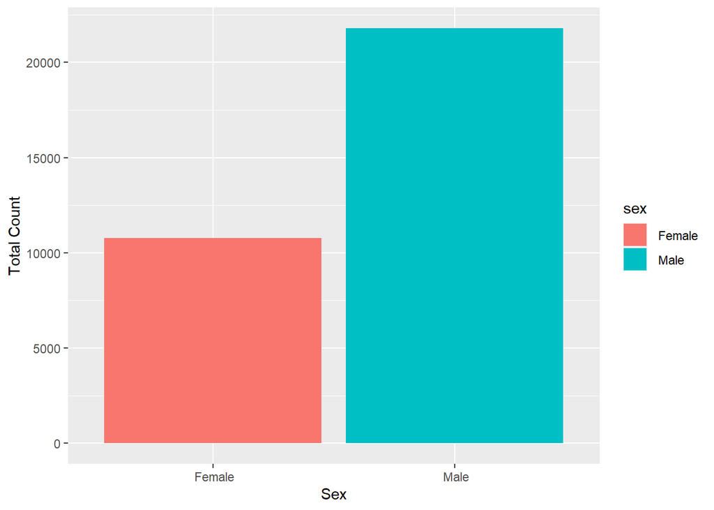

```r
#which(is.na(census_data))

#Plotting sex variable
ggplot(census_data, aes(x= sex,fill= sex))+geom_bar()+xlab("Sex")+ylab("Total Count")
```

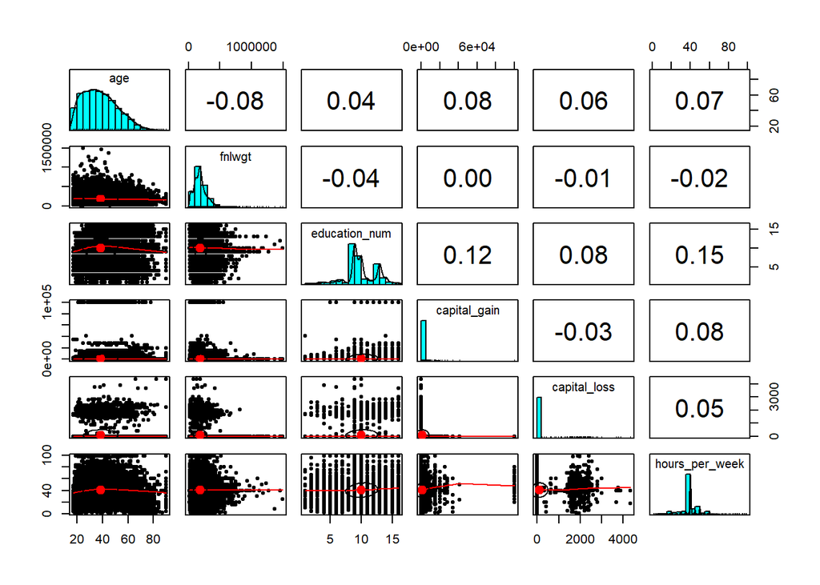

```r
#Observing correlation and histogram of all numeric column
pairs.panels(census_data[c(1,3,5,11,12,13)])
```

```r
#Counting total elements present in each column
table(census_data$workclass)
```

```
##
##                 ?       Federal-gov         Local-gov      Never-worked
##              1836               960              2093                 7
##           Private      Self-emp-inc  Self-emp-not-inc         State-gov
##             22696              1116              2541              1298
##       Without-pay
##                14
```

```r
table(census_data$education)
```

```
##
##          10th          11th          12th       1st-4th       5th-6th
##           933          1175           433           168           333
##       7th-8th           9th    Assoc-acdm     Assoc-voc     Bachelors
##           646           514          1067          1382          5355
##     Doctorate       HS-grad       Masters     Preschool   Prof-school
##           413         10501          1723            51           576
##  Some-college
##          7291
```

```r
table(census_data$martial_status)
```

```
##
##               Divorced      Married-AF-spouse     Married-civ-spouse
##                   4443                     23                  14976
##  Married-spouse-absent          Never-married              Separated
##                    418                  10683                   1025
##                Widowed
##                    993
```

```r
table(census_data$occupation)
```

```
##
##                  ?       Adm-clerical       Armed-Forces       Craft-repair
##               1843               3770                  9               4099
##    Exec-managerial    Farming-fishing  Handlers-cleaners  Machine-op-inspct
##               4066                994               1370               2002
##      Other-service    Priv-house-serv     Prof-specialty    Protective-serv
##               3295                149               4140                649
##              Sales       Tech-support   Transport-moving
##               3650                928               1597
```

```r
table(census_data$relationship)
```

```
##
##         Husband   Not-in-family  Other-relative       Own-child       Unmarried
##           13193            8305             981            5068            3446
##            Wife
##            1568
```

```r
table(census_data$race)
```

```
##
##  Amer-Indian-Eskimo  Asian-Pac-Islander               Black               Other
##                 311                1039                3124                 271
##               White
##               27816
```

```r
table(census_data$sex)
```

```
##
##  Female    Male
##   10771   21790
```

```r
table(census_data$native_country)
```

```
##
##                           ?                    Cambodia
##                         583                          19
##                      Canada                       China
##                         121                          75
##                    Columbia                        Cuba
##                          59                          95
##          Dominican-Republic                     Ecuador
##                          70                          28
##                 El-Salvador                     England
##                         106                          90
##                      France                     Germany
##                          29                         137
##                      Greece                   Guatemala
##                          29                          64
##                       Haiti          Holand-Netherlands
##                          44                           1
##                    Honduras                        Hong
##                          13                          20
##                     Hungary                       India
##                          13                         100
##                        Iran                     Ireland
##                          43                          24
##                       Italy                     Jamaica
##                          73                          81
##                       Japan                        Laos
##                          62                          18
##                      Mexico                   Nicaragua
##                         643                          34
##  Outlying-US(Guam-USVI-etc)                        Peru
##                          14                          31
##                 Philippines                      Poland
##                         198                          60
##                    Portugal                 Puerto-Rico
##                          37                         114
##                    Scotland                       South
##                          12                          80
##                      Taiwan                    Thailand
##                          51                          18
##             Trinadad&Tobago               United-States
##                          19                       29170
##                     Vietnam                  Yugoslavia
##                          67                          16
```

```r
table(census_data$Class)
```

```
##
##  <=50K   >50K
##  24720   7841
```

```r
# We observe that an unknown character '?' is present for the following categorical variables workclass,occupation,native_country
getmode <- function(v)
{
  uniqv <- unique(v)
  uniqv[which.max(tabulate(match(v, uniqv)))]
}

census_data[census_data == ' ?'] <- NA
census_data$workclass[is.na(census_data$workclass)] <- getmode(census_data$workclass)
census_data$occupation[is.na(census_data$occupation)] <- getmode(census_data$occupation)
census_data$native_country[is.na(census_data$native_country)] <- getmode(census_data$native_country)
```

- Creating a sample test case needed for problem 7.
- Converting age to categorical variable using ifelse conditions
- Converting all categorical variables to factors

```r
#Creating Test case needed for problem 7
census_data[32562,1] <- as.integer(35)
census_data[32562,c(2,4,9,10,14)] <- c(" Local-gov"," Doctorate"," White", " Female"," Portugal")
str(census_data)
```

```
## 'data.frame':    32562 obs. of  15 variables:
##  $ age           : int  39 50 38 53 28 37 49 52 31 42 ...
##  $ workclass     : chr  " State-gov" " Self-emp-not-inc" " Private" " Private" ...
##  $ fnlwgt        : int  77516 83311 215646 234721 338409 284582 160187 209642 45781 159449 ...
##  $ education     : chr  " Bachelors" " Bachelors" " HS-grad" " 11th" ...
##  $ education_num : int  13 13 9 7 13 14 5 9 14 13 ...
##  $ martial_status: chr  " Never-married" " Married-civ-spouse" " Divorced" " Married-civ-spouse" ...
##  $ occupation    : chr  " Adm-clerical" " Exec-managerial" " Handlers-cleaners" " Handlers-cleaners" ...
##  $ relationship  : chr  " Not-in-family" " Husband" " Not-in-family" " Husband" ...
##  $ race          : chr  " White" " White" " White" " Black" ...
##  $ sex           : chr  " Male" " Male" " Male" " Male" ...
##  $ capital_gain  : int  2174 0 0 0 0 0 0 0 14084 5178 ...
##  $ capital_loss  : int  0 0 0 0 0 0 0 0 0 0 ...
##  $ hours_per_week: int  40 13 40 40 40 40 16 45 50 40 ...
##  $ native_country: chr  " United-States" " United-States" " United-States" " United-States" ...
##  $ Class         : chr  " <=50K" " <=50K" " <=50K" " <=50K" ...
```

```r
#Getting the range for categorical distribution of age
quantile(census_data$age)
```

```
##   0%  25%  50%  75% 100%
##   17   28   37   48   90
```

```r
census_data$age <- as.factor(ifelse(census_data$age >=17 & census_data$age < 28, '1', ifelse(census_data$age >=28 & census_data$age < 37, '2',ifelse(census_data$age >=37 & census_data$age < 48, '3','4'))))

#Converting all categorical variables to factors
census_data$education <- as.factor(census_data$education)
census_data$workclass <- as.factor(census_data$workclass)
census_data$sex <- as.factor(census_data$sex)
census_data$race <- as.factor(census_data$race)
census_data$native_country <- as.factor(census_data$native_country)
census_data$Class <- as.factor(census_data$Class)

#Test case for problem 7
test <- census_data[32562,c(1,2,4,9,10,14)]
census_data <- census_data[-32562,]
```

3. Split the data set 75/25 so you retain 25% for testing using random sampling.
- Partitioning data using caret package.
- Splitting data in 75-25% using p = 0.75

```r
#Setting seed to 101 for getting random values
set.seed(101)

#Creating index of partitioned data and assigning to training and testing data
index <- createDataPartition(census_data$Class, p=0.75, list = FALSE, times = 1)
training_data <- census_data[index, ]
testing_data <- census_data[-index, ]

#Exploring testing and training dataset
str(testing_data)
```

```
## 'data.frame':    8140 obs. of  15 variables:
##  $ age           : Factor w/ 4 levels "1","2","3","4": 4 3 3 4 2 2 2 2 4 1 ...
##  $ workclass     : Factor w/ 8 levels " Federal-gov",..: 6 4 4 6 7 4 4 1 4 2 ...
##  $ fnlwgt        : int  83311 215646 284582 209642 141297 245487 186824 76845 193366 190709 ...
##  $ education     : Factor w/ 16 levels " 10th"," 11th",..: 10 12 13 12 10 6 12 7 12 8 ...
##  $ education_num : int  13 9 14 9 13 4 9 5 9 12 ...
##  $ martial_status: chr  " Married-civ-spouse" " Divorced" " Married-civ-spouse" " Married-civ-spouse" ...
##  $ occupation    : chr  " Exec-managerial" " Handlers-cleaners" " Exec-managerial" " Exec-managerial" ...
##  $ relationship  : chr  " Husband" " Not-in-family" " Wife" " Husband" ...
##  $ race          : Factor w/ 5 levels " Amer-Indian-Eskimo",..: 5 5 5 5 2 1 5 3 5 5 ...
##  $ sex           : Factor w/ 2 levels " Female"," Male": 2 2 1 2 2 2 2 2 2 2 ...
##  $ capital_gain  : int  0 0 0 0 0 0 0 0 0 0 ...
##  $ capital_loss  : int  0 0 0 0 0 0 0 0 0 0 ...
##  $ hours_per_week: int  13 40 40 45 40 45 40 40 40 52 ...
##  $ native_country: Factor w/ 41 levels " Cambodia"," Canada",..: 39 39 39 39 19 26 39 39 39 39 ...
##  $ Class         : Factor w/ 2 levels " <=50K"," >50K": 1 1 1 2 2 1 1 1 1 1 ...
```

```r
str(training_data)
```

```
## 'data.frame':    24421 obs. of  15 variables:
##  $ age           : Factor w/ 4 levels "1","2","3","4": 3 4 2 4 2 3 3 1 2 3 ...
##  $ workclass     : Factor w/ 8 levels " Federal-gov",..: 7 4 4 4 4 4 4 4 4 4 ...
##  $ fnlwgt        : int  77516 234721 338409 160187 45781 159449 280464 122272 205019 121772 ...
##  $ education     : Factor w/ 16 levels " 10th"," 11th",..: 10 2 10 7 13 10 16 10 8 9 ...
##  $ education_num : int  13 7 13 5 14 13 10 13 12 11 ...
##  $ martial_status: chr  " Never-married" " Married-civ-spouse" " Married-civ-spouse" " Married-spouse-absent" ...
##  $ occupation    : chr  " Adm-clerical" " Handlers-cleaners" " Prof-specialty" " Other-service" ...
##  $ relationship  : chr  " Not-in-family" " Husband" " Wife" " Not-in-family" ...
##  $ race          : Factor w/ 5 levels " Amer-Indian-Eskimo",..: 5 3 3 3 5 5 3 5 3 2 ...
##  $ sex           : Factor w/ 2 levels " Female"," Male": 2 2 1 1 1 2 2 1 2 2 ...
##  $ capital_gain  : int  2174 0 0 0 14084 5178 0 0 0 0 ...
##  $ capital_loss  : int  0 0 0 0 0 0 0 0 0 0 ...
##  $ hours_per_week: int  40 40 40 16 50 40 80 30 50 40 ...
##  $ native_country: Factor w/ 41 levels " Cambodia"," Canada",..: 39 39 5 23 39 39 39 39 39 39 ...
##  $ Class         : Factor w/ 2 levels " <=50K"," >50K": 1 1 1 1 2 2 2 1 1 2 ...
```

4. Using the Naive Bayes Classification algorithm from the KlaR, naivebayes, and e1071 packages, build an ensemble classifier that predicts whether an individual earns more than or less than US$50,000. Only use the features age, education, workclass, sex, race, and native-country. Ignore any other features in your model. You need to transform continuous variables into categorical variables by binning (use equal size bins from in to max). Note that some packages might not work with your current version of R and may need to be downgraded.
- Using klaR, naiveBayes and e1071 libraries to create predition objects using training data
- Creating an ensemble model by using majority prediction method.
- Testing the ensemble model on testing dataset

```r
#Creating klaR, naiveBayes and e1071 predictors
klar_nb <- klaR::NaiveBayes(Class~age+education+workclass+sex+race+native_country, data = training_data)

naiveBayes_nb <- naivebayes::naive_bayes(Class~age+education+workclass+sex+race+native_country, data = training_data, laplace = 1)

e1071_nb <- e1071::naiveBayes(Class~age+education+workclass+sex+race+native_country, data = training_data)

#Creating an ensemble model using majority prediction method
ensemble_model <- function(data){

  prediction_klar <- predict(klar_nb, data)[[1]]
  prediction_naive <- predict(naiveBayes_nb,data)
  prediction_e1071 <- predict(e1071_nb,data)

 Output <- data.frame("klaR" = prediction_klar, "NaiveBayes" = prediction_naive, "E1071" = prediction_e1071, "Major_Vote" = as.factor(ifelse(prediction_klar ==' >50K' & prediction_naive==' >50K',' >50K',ifelse(prediction_klar==' >50K' & prediction_e1071==' >50K',' >50K',ifelse(prediction_naive==' >50K' & prediction_e1071==' >50K',' >50K',' <=50K')))))

 return(Output)
}

#Testing the model on testing data
ensemble_model(testing_data[,c(1,2,4,9,10,14)])
```

|  | klaR | NaiveBayes | E1071 | Major_Vote |
| --- | --- | --- | --- | --- |
| 2 | >50K | >50K | >50K | >50K |
| 3 | <=50K | <=50K | <=50K | <=50K |
| 6 | <=50K | <=50K | <=50K | <=50K |
| 8 | <=50K | <=50K | <=50K | <=50K |
| 12 | >50K | >50K | >50K | >50K |
| 16 | <=50K | <=50K | <=50K | <=50K |
| 18 | <=50K | <=50K | <=50K | <=50K |
| 23 | <=50K | <=50K | <=50K | <=50K |
| 30 | <=50K | <=50K | <=50K | <=50K |
| 31 | <=50K | <=50K | <=50K | <=50K |

[output cut: 8130 more lines]

5. Create a full logistic regression model of the same features as in (4) (i.e., do not eliminate any features regardless of p-value). Be sure to either use dummy coding for categorical features or convert them to factor variables and ensure that the glm function does the dummy coding.
6. Add the logistic regression model to the ensemble built in (4).
- Using glm for creating logistic regression model by selecting all features
- Adding the logistic model to the above ensemble model
- Testing the new ensemble model using testing dataset

```r
#Creating a logistic regression model using glm function
log_reg <- glm(Class~age+education+workclass+sex+race+native_country, data = training_data, family = binomial(link = "logit"))

#Updating ensemble model by adding logistic regression
ensemble_model <- function(data){

  prediction_klar <- predict(klar_nb, data)[[1]]
  prediction_naive <- predict(naiveBayes_nb,data)
  prediction_e1071 <- predict(e1071_nb,data)
  prediction_log <- ifelse(predict(log_reg, data,type = "response") < 0.5, " <=50K"," >50K")

 Output <- data.frame("klaR" = prediction_klar, "NaiveBayes" = prediction_naive, "E1071" = prediction_e1071,"LogisticRegression" = prediction_log, "Major_Vote" = as.factor(ifelse(prediction_klar == ' >50K' & prediction_naive == ' >50K' & prediction_e1071 == ' >50K', ' >50K', ifelse(prediction_klar == ' >50K' & prediction_naive == ' >50K' & prediction_log == ' >50K', ' >50K', ifelse(prediction_naive == ' >50K' & prediction_e1071 == ' >50K' & prediction_log == ' >50K', ' >50K', ' <=50K')))))

 return(Output)
}

#Testing new ensemble model
ensemble_model(testing_data[,c(1,2,4,9,10,14)])
```

|  | klaR | NaiveBayes | E1071 | LogisticRegression | Major_Vote |
| --- | --- | --- | --- | --- | --- |
| 2 | >50K | >50K | >50K | >50K | >50K |
| 3 | <=50K | <=50K | <=50K | <=50K | <=50K |
| 6 | <=50K | <=50K | <=50K | <=50K | <=50K |
| 8 | <=50K | <=50K | <=50K | <=50K | <=50K |
| 12 | >50K | >50K | >50K | <=50K | >50K |
| 16 | <=50K | <=50K | <=50K | <=50K | <=50K |
| 18 | <=50K | <=50K | <=50K | <=50K | <=50K |
| 23 | <=50K | <=50K | <=50K | <=50K | <=50K |
| 30 | <=50K | <=50K | <=50K | <=50K | <=50K |
| 31 | <=50K | <=50K | <=50K | <=50K | <=50K |

[output cut: 8130 more lines]

7. Using the ensemble model from (6), predict whether a 35-year-old white female adult who is a local government worker with a doctorate who immigrated from Portugal earns more or less than US$50,000.
- Using the test object created before for predicting the output
- Based on the ensemble model we can say that the female adult earns less than 50K salary

```r
#Test case created before
test
```

|  | age | workclass | education | race | sex | native_country |
| --- | --- | --- | --- | --- | --- | --- |
| 32562 | 2 | Local-gov | Doctorate | White | Female | Portugal |

```r
#Predicting output for the test case
ensemble_model(test)
```

|  | klaR | NaiveBayes | E1071 | LogisticRegression | Major_Vote |
| --- | --- | --- | --- | --- | --- |
| 32562 | <=50K | <=50K | <=50K | <=50K | <=50K |

8. Calculate accuracy and prepare confusion matrices for all three Bayes implementations (KlaR, naivebayes, e1071) and the logistic regression model. Compare the implementations and comment on differences. Be sure to use the same training data set for all three. The results should be the same but they may differ if the different implementations deal differently with LaPalace Estimators.
- We use table function to get the total number of true positive and true negative predictions
- We calculate the accuracy with the help of true positive and true negative values
- COnfusionMatrix function is used to get the accuracy of the model
- We see that for klaR and e1071 we get the same accuracy which is 79.65602%, for naiveBayes we get an increased accuracy of 79.68059% since we use laplace estimators. Out of all 4 models logistic regression model performs the best with an accuracy of 80.13514%

```r
#Predicting the accuracy of the klaR model by using testing dataset
prediction <- predict(klar_nb, testing_data[,c(1,2,4,9,10,14)])
table(prediction$class, testing_data$Class)
```

```
##
##           <=50K  >50K
##    <=50K   5633  1109
##    >50K     547   851
```

```r
confusionMatrix(table(prediction$class, testing_data$Class))
```

```
## Confusion Matrix and Statistics
##
##
##           <=50K  >50K
##    <=50K   5633  1109
##    >50K     547   851
##
##                Accuracy : 0.7966
##                  95% CI : (0.7876, 0.8053)
##     No Information Rate : 0.7592
##     P-Value [Acc > NIR] : 5.458e-16
##
##                   Kappa : 0.3832
##
##  Mcnemar's Test P-Value : < 2.2e-16
##
##             Sensitivity : 0.9115
##             Specificity : 0.4342
##          Pos Pred Value : 0.8355
##          Neg Pred Value : 0.6087
##              Prevalence : 0.7592
##          Detection Rate : 0.6920
##    Detection Prevalence : 0.8283
##       Balanced Accuracy : 0.6728
##
##        'Positive' Class :  <=50K
##
```

```r
#Predicting the accuracy of the naiveBayes model by using testing dataset
prediction_naive <- predict(naiveBayes_nb, testing_data[,c(1,2,4,9,10,14)])
table(prediction_naive, testing_data$Class)
```

```
##
## prediction_naive  <=50K  >50K
##            <=50K   5635  1109
##            >50K     545   851
```

```r
confusionMatrix(table(prediction_naive, testing_data$Class))
```

```
## Confusion Matrix and Statistics
##
##
## prediction_naive  <=50K  >50K
##            <=50K   5635  1109
##            >50K     545   851
##
##                Accuracy : 0.7968
##                  95% CI : (0.7879, 0.8055)
##     No Information Rate : 0.7592
##     P-Value [Acc > NIR] : 3.514e-16
##
##                   Kappa : 0.3837
##
##  Mcnemar's Test P-Value : < 2.2e-16
##
##             Sensitivity : 0.9118
##             Specificity : 0.4342
##          Pos Pred Value : 0.8356
##          Neg Pred Value : 0.6096
##              Prevalence : 0.7592
##          Detection Rate : 0.6923
##    Detection Prevalence : 0.8285
##       Balanced Accuracy : 0.6730
##
##        'Positive' Class :  <=50K
##
```

```r
#Predicting the accuracy of the e1071 model by using testing dataset
prediction_e1071 <- predict(e1071_nb, testing_data[,c(1,2,4,9,10,14)])
table(prediction_e1071, testing_data$Class)
```

```
##
## prediction_e1071  <=50K  >50K
##            <=50K   5633  1109
##            >50K     547   851
```

```r
confusionMatrix(table(prediction_e1071, testing_data$Class))
```

```
## Confusion Matrix and Statistics
##
##
## prediction_e1071  <=50K  >50K
##            <=50K   5633  1109
##            >50K     547   851
##
##                Accuracy : 0.7966
##                  95% CI : (0.7876, 0.8053)
##     No Information Rate : 0.7592
##     P-Value [Acc > NIR] : 5.458e-16
##
##                   Kappa : 0.3832
##
##  Mcnemar's Test P-Value : < 2.2e-16
##
##             Sensitivity : 0.9115
##             Specificity : 0.4342
##          Pos Pred Value : 0.8355
##          Neg Pred Value : 0.6087
##              Prevalence : 0.7592
##          Detection Rate : 0.6920
##    Detection Prevalence : 0.8283
##       Balanced Accuracy : 0.6728
##
##        'Positive' Class :  <=50K
##
```

```r
#Predicting the accuracy of the logistic regression model by using testing dataset
log_predict <- round(predict(log_reg, newdata = testing_data, type = "response"),0)
log_predict_new <- unname(log_predict)
table(log_predict_new, as.numeric(ifelse(testing_data$Class == " <=50K",0,1)))
```

```
##
## log_predict_new    0    1
##               0 5764 1201
##               1  416  759
```

```r
confusionMatrix(table(log_predict_new, as.numeric(ifelse(testing_data$Class == " <=50K",0,1))))
```

```
## Confusion Matrix and Statistics
##
##
## log_predict_new    0    1
##               0 5764 1201
##               1  416  759
##
##                Accuracy : 0.8014
##                  95% CI : (0.7925, 0.81)
##     No Information Rate : 0.7592
##     P-Value [Acc > NIR] : < 2.2e-16
##
##                   Kappa : 0.3706
##
##  Mcnemar's Test P-Value : < 2.2e-16
##
##             Sensitivity : 0.9327
##             Specificity : 0.3872
##          Pos Pred Value : 0.8276
##          Neg Pred Value : 0.6460
##              Prevalence : 0.7592
##          Detection Rate : 0.7081
##    Detection Prevalence : 0.8557
##       Balanced Accuracy : 0.6600
##
##        'Positive' Class : 0
##
```

```r
#Calculating accuracy of each model by using the true positive and negative values from the table function
klar_acc <- (5633+851)/8140*100
naiveBayes_acc <- (5635+851)/8140*100
e1071_acc <- (5633+851)/8140*100
logistic_acc <- (5764+759)/8140*100

#Accuracy of all models
Accuracy <- data.frame("klaR" = klar_acc, "naiveBayes" = naiveBayes_acc, "e1071" = e1071_acc, "Logistic Regression" = logistic_acc)

Accuracy
```

| klaR | naiveBayes | e1071 | Logistic.Regression |
| --- | --- | --- | --- |
| 79.65602 | 79.68059 | 79.65602 | 80.13514 |

```
                                            ----- Problem 2 -----
```

1. Load and then explore the data set on car sales referenced by the article Shonda Kuiper (2008) Introduction to Multiple Regression: How Much Is Your Car Worth?
- Importing cars dataset and exploring the dataset
- We use head and str function to explore the structure of the dataset
- Pairs.panels function is used to observe the correlations and histogram of all the columns present

```r
#Importing cars dataset
cars_data <- read.csv("C:\\Users\\harsh\\Desktop\\Introduction to Machine learning and Data Mining\\Practicum-2\\car_data.csv",stringsAsFactors = FALSE)

#Renaming the first column
names(cars_data)[names(cars_data) == "ï..Price"] <- "Price"

#Exploring dataset
str(cars_data)
```

```
## 'data.frame':    804 obs. of  9 variables:
##  $ Price   : num  17314 17542 16219 16337 16339 ...
##  $ Mileage : int  8221 9135 13196 16342 19832 22236 22576 22964 24021 27325 ...
##  $ Make    : chr  "Buick" "Buick" "Buick" "Buick" ...
##  $ Cylinder: int  6 6 6 6 6 6 6 6 6 6 ...
##  $ Liter   : num  3.1 3.1 3.1 3.1 3.1 3.1 3.1 3.1 3.1 3.1 ...
##  $ Doors   : int  4 4 4 4 4 4 4 4 4 4 ...
##  $ Cruise  : int  1 1 1 1 1 1 1 1 1 1 ...
##  $ Sound   : int  1 1 1 0 0 1 1 1 0 1 ...
##  $ Leather : int  1 0 0 0 1 0 0 0 1 1 ...
```

```r
head(cars_data)
```

|  | Price | Mileage | Make | Cylinder | Liter | Doors | Cruise | Sound | Leather |
| --- | --- | --- | --- | --- | --- | --- | --- | --- | --- |
| 1 | 17314.10 | 8221 | Buick | 6 | 3.1 | 4 | 1 | 1 | 1 |
| 2 | 17542.04 | 9135 | Buick | 6 | 3.1 | 4 | 1 | 1 | 0 |
| 3 | 16218.85 | 13196 | Buick | 6 | 3.1 | 4 | 1 | 1 | 0 |
| 4 | 16336.91 | 16342 | Buick | 6 | 3.1 | 4 | 1 | 0 | 0 |
| 5 | 16339.17 | 19832 | Buick | 6 | 3.1 | 4 | 1 | 0 | 1 |
| 6 | 15709.05 | 22236 | Buick | 6 | 3.1 | 4 | 1 | 1 | 0 |

```r
summary(cars_data)
```

```
##      Price          Mileage          Make              Cylinder
##  Min.   : 8639   Min.   :  266   Length:804         Min.   :4.000
##  1st Qu.:14273   1st Qu.:14624   Class :character   1st Qu.:4.000
##  Median :18025   Median :20914   Mode  :character   Median :6.000
##  Mean   :21343   Mean   :19832                      Mean   :5.269
##  3rd Qu.:26717   3rd Qu.:25213                      3rd Qu.:6.000
##  Max.   :70755   Max.   :50387                      Max.   :8.000
##      Liter           Doors           Cruise           Sound
##  Min.   :1.600   Min.   :2.000   Min.   :0.0000   Min.   :0.0000
##  1st Qu.:2.200   1st Qu.:4.000   1st Qu.:1.0000   1st Qu.:0.0000
##  Median :2.800   Median :4.000   Median :1.0000   Median :1.0000
##  Mean   :3.037   Mean   :3.527   Mean   :0.7525   Mean   :0.6791
##  3rd Qu.:3.800   3rd Qu.:4.000   3rd Qu.:1.0000   3rd Qu.:1.0000
##  Max.   :6.000   Max.   :4.000   Max.   :1.0000   Max.   :1.0000
##     Leather
##  Min.   :0.0000
##  1st Qu.:0.0000
##  Median :1.0000
##  Mean   :0.7239
##  3rd Qu.:1.0000
##  Max.   :1.0000
```

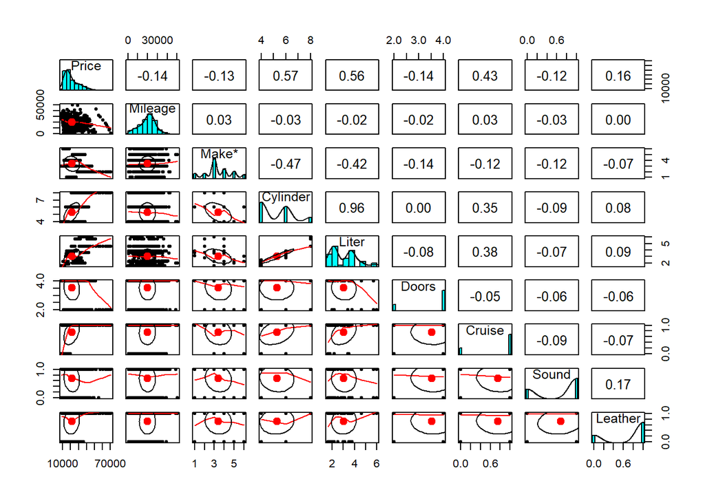

```r
#Plotting all the columns using pairs.panels function
pairs.panels(cars_data)
```

- Creating a sample test cases needed for problem 2.9
- Converting categorical variable to factor

```r
cars_data[805,2] <- as.integer(61435)
cars_data[805,3] <- as.character("SAAB")
cars_data[805,4] <- as.integer(4)
cars_data[805,5] <- as.numeric(2.3)
cars_data[805,6] <- as.integer(4)
cars_data[805,7] <- as.integer(1)
cars_data[805,8] <- as.integer(1)
cars_data[805,9] <- as.integer(1)

cars_data$Make <- as.factor(cars_data$Make)

sample <- cars_data[805,]

cars_data <- cars_data[-805,]
```

2. Are there outliers in the data set? How do you identify outliers and how do you deal with them? Remove them but create a second data set with outliers removed. Keep the original data set.
- First we use boxplot function as it helps in observing possible outliers
- Later we use z-score method to get the outliers which are 3 std deviations away
- We observe that outliers are present for price and mileage column
- We use mean imputation method for dealing with outliers
- After imputation we remove the outliers and add it to new cars variable which is used in problem 2.7

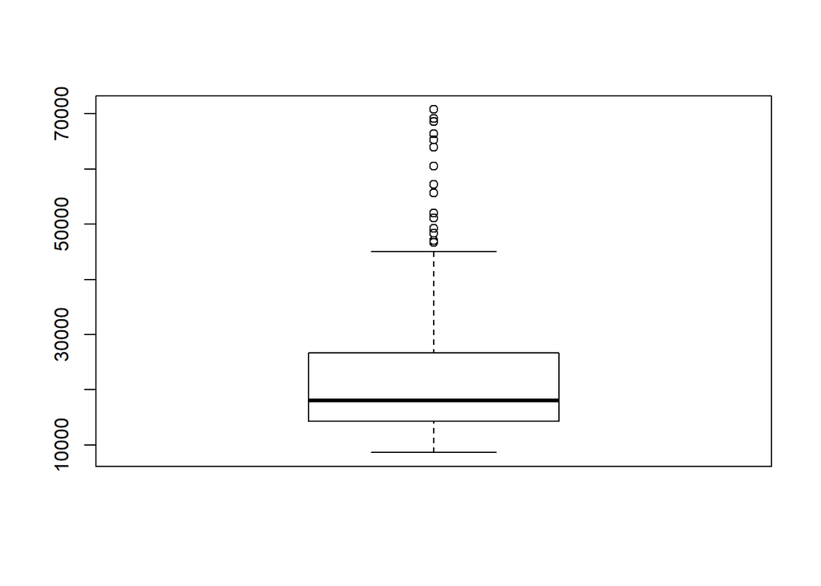

```r
#Boxplot is used to observe possible outliers
boxplot(cars_data$Price)
```

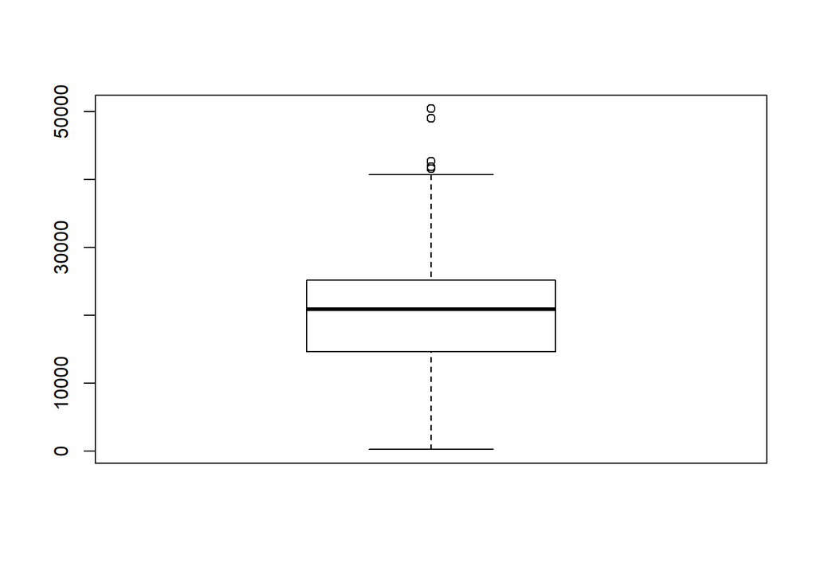

```r
boxplot(cars_data$Mileage)
```

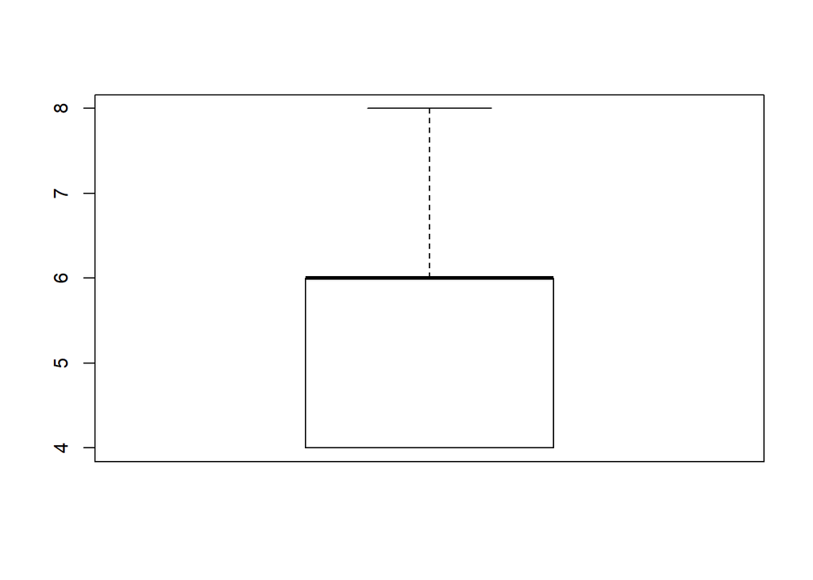

```r
boxplot(cars_data$Cylinder)
```

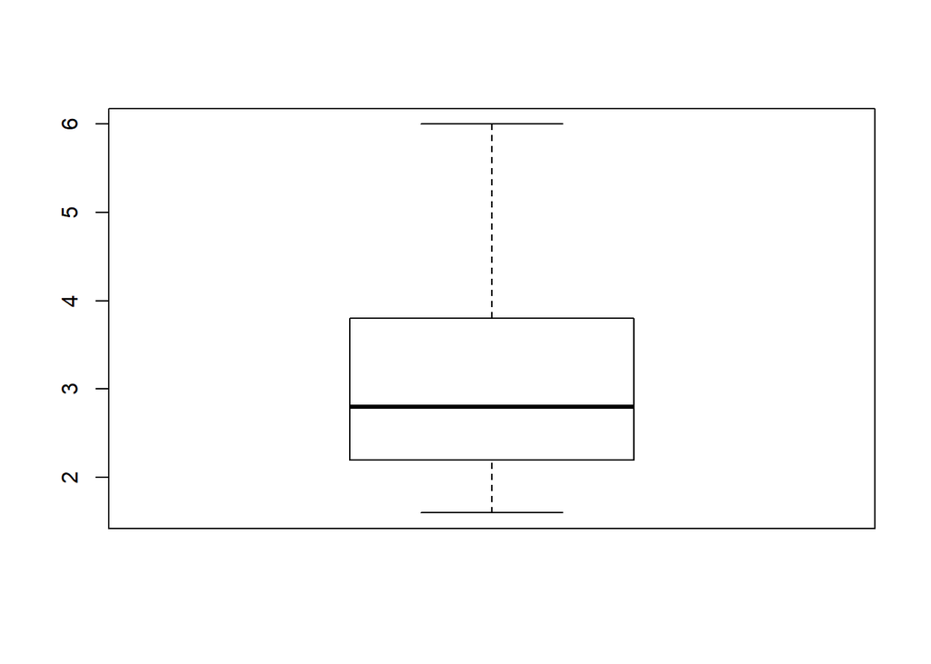

```r
boxplot(cars_data$Liter)
```

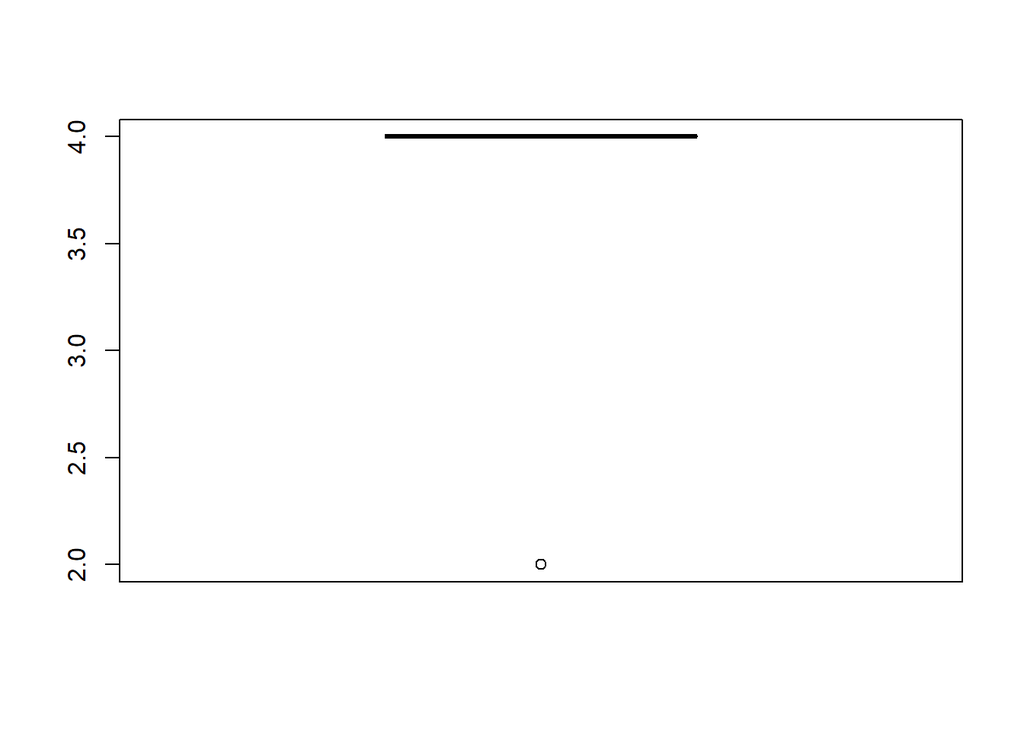

```r
boxplot(cars_data$Doors)
```

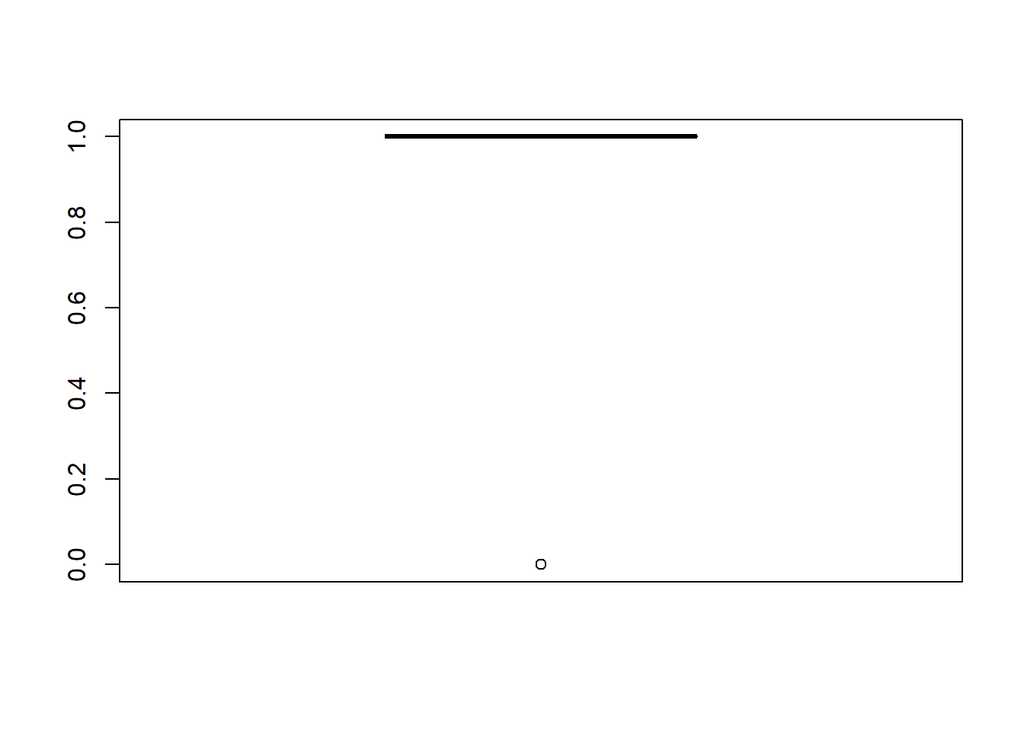

```r
boxplot(cars_data$Cruise)
```

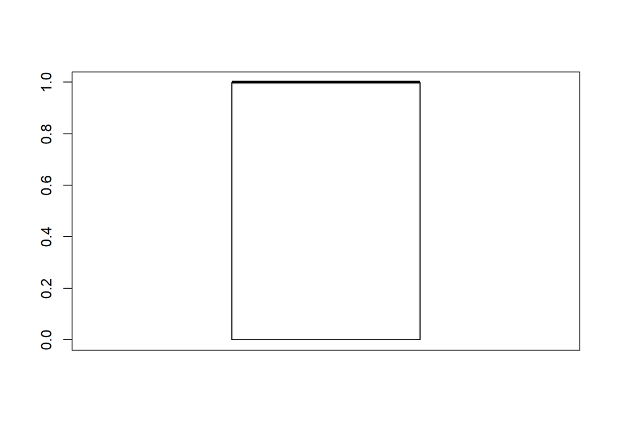

```r
boxplot(cars_data$Sound)
```

```r
#Using z-score method for finding possible outliers
cars_outlier <- cars_data
for (i in c(1,2,4,5,6,7,8,9))
  {
    mean_data <- mean(cars_outlier[,i])
    sd_data <- sd(cars_outlier[,i])
    zscore <- abs((cars_outlier[,i]-mean_data)/sd_data)
    cars_outlier[which(!(zscore>3)),i] = NA
    print(which(is.na(cars_outlier[,i])==FALSE))
    }
```

```
##  [1]  81 151 152 153 154 155 156 157 158 159 160
## [1] 650 680
## integer(0)
## integer(0)
## integer(0)
## integer(0)
## integer(0)
## integer(0)
```

```r
cars_outlier
```

|  | Price | Mileage | Make | Cylinder | Liter | Doors | Cruise | Sound | Leather |
| --- | --- | --- | --- | --- | --- | --- | --- | --- | --- |
| 1 | NA | NA | Buick | NA | NA | NA | NA | NA | NA |
| 2 | NA | NA | Buick | NA | NA | NA | NA | NA | NA |
| 3 | NA | NA | Buick | NA | NA | NA | NA | NA | NA |
| 4 | NA | NA | Buick | NA | NA | NA | NA | NA | NA |
| 5 | NA | NA | Buick | NA | NA | NA | NA | NA | NA |
| 6 | NA | NA | Buick | NA | NA | NA | NA | NA | NA |
| 7 | NA | NA | Buick | NA | NA | NA | NA | NA | NA |
| 8 | NA | NA | Buick | NA | NA | NA | NA | NA | NA |
| 9 | NA | NA | Buick | NA | NA | NA | NA | NA | NA |
| 10 | NA | NA | Buick | NA | NA | NA | NA | NA | NA |

[output cut: 794 more lines]

```r
#Creating a duplicate dataset for adding new data without outliers
cars_data_new <- cars_data

#Imputing the outliers with mean values
cars_data_new[c(81,160,159,158,157,156,155,154,153,152,151),1] <- mean(cars_data_new[,1],na.rm = TRUE)
cars_data_new[c(680,650),2] <- mean(cars_data_new[,2],na.rm = TRUE)

#Removing outliers by assigning NA values first and later using na.rm all functions
cars_data_new[c(81,160,159,158,157,156,155,154,153,152,151),1] <- NA
cars_data_new[c(680,650),2] <- NA
```

3. What are the distributions of each of the features in the data set with outliers removed? Are they reasonably normal so you can apply a statistical learner such as regression? Can you normalize features through a log, inverse, or square-root transform? Transform as needed.
- We use pairs.panels and hist function to plot the histogram of each column
- We see that Mileage is fairly normalized data so we can make use of the data without normalization
- Price and liter column are not normally distributed so we will use log transformation.
- After trying transformation on price and liter we use skewness function
- We observe that price function is almost normally distributed and that the skewness is very less with log10 transformation. So we use log10 transformation for price column.
- About liter column, we observe no change in the data even with transformation so we select the data as it is.
- Cylinder, Doors, Cruise, Leather, Sound are categorical no need for distribution transformation.

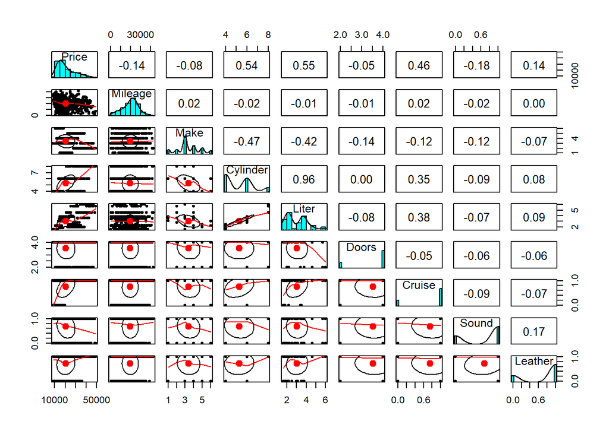

```r
#Plotting histogram of each column to observe the distribution
pairs.panels(cars_data_new)
```

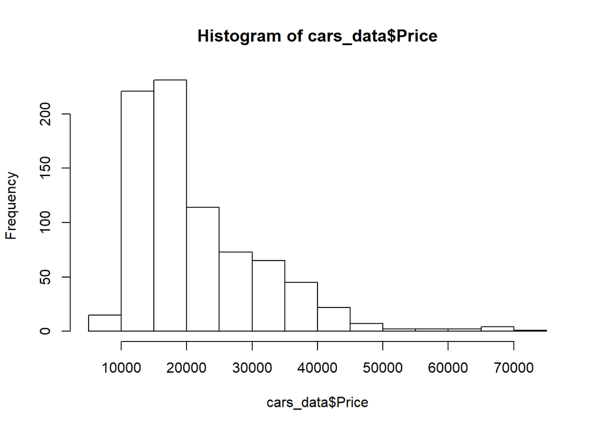

```r
#Comparing histogram of price and mileage before removing outliers and after removing outliers
hist(cars_data$Price)
```

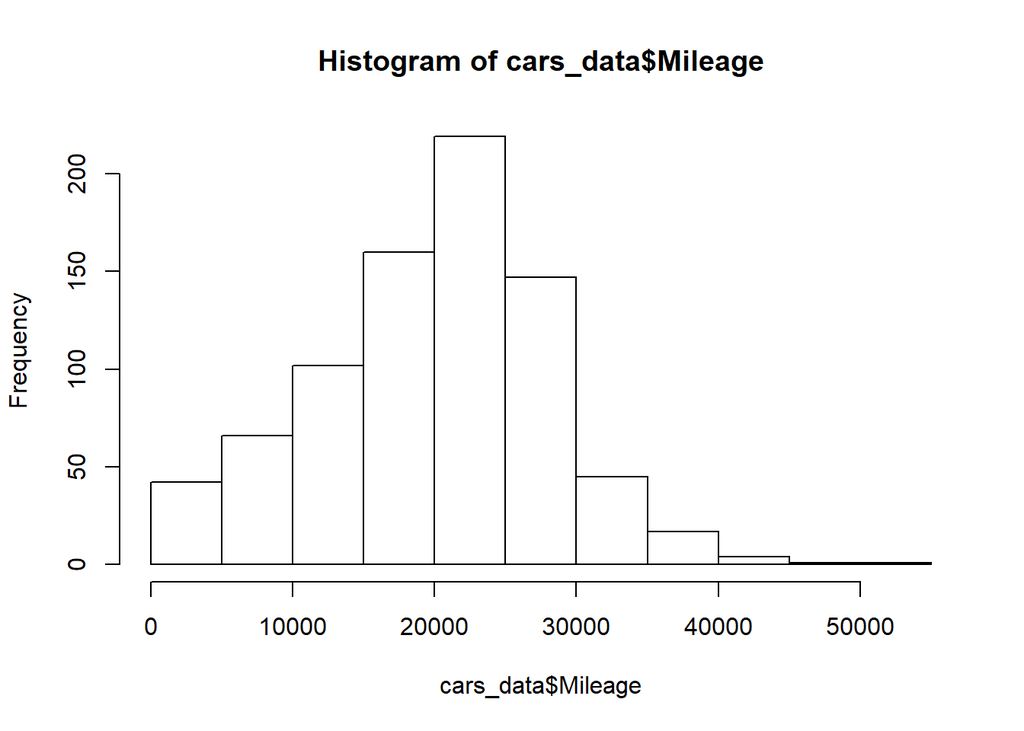

```r
hist(cars_data$Mileage)
```

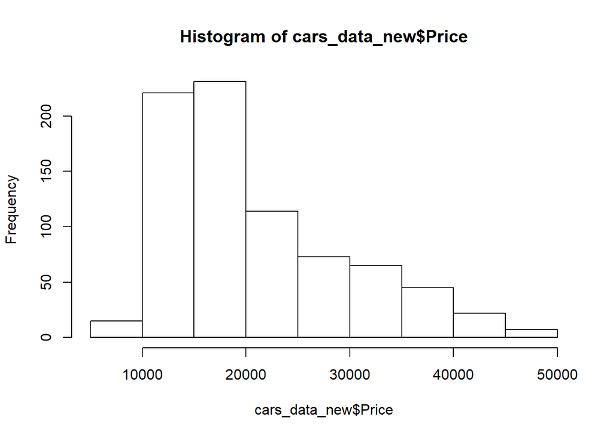

```r
hist(cars_data_new$Price)
```

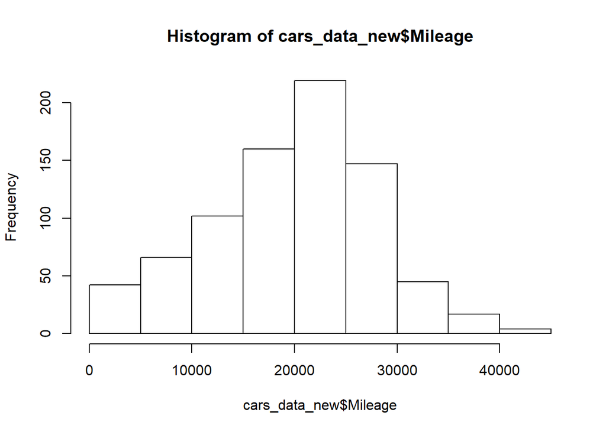

```r
hist(cars_data_new$Mileage)
```

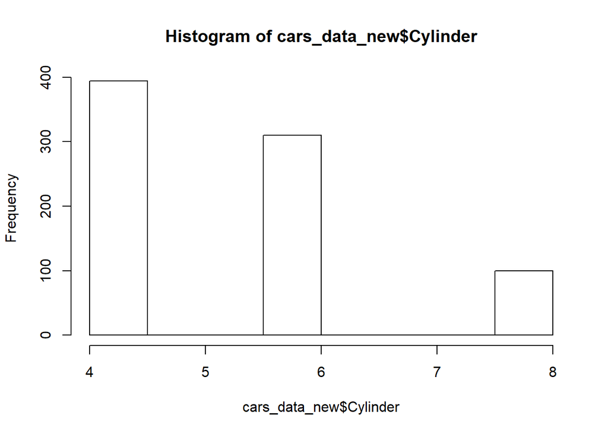

```r
#Histogram for all other columns
hist(cars_data_new$Cylinder)
```

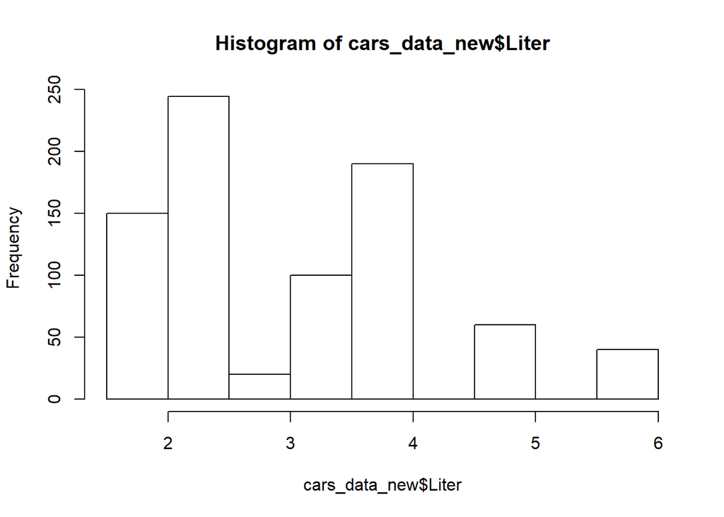

```r
hist(cars_data_new$Liter)
```

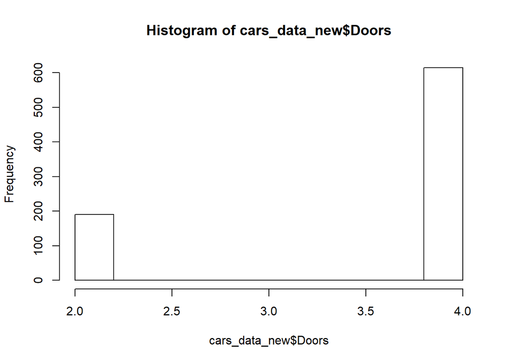

```r
hist(cars_data_new$Doors)
```

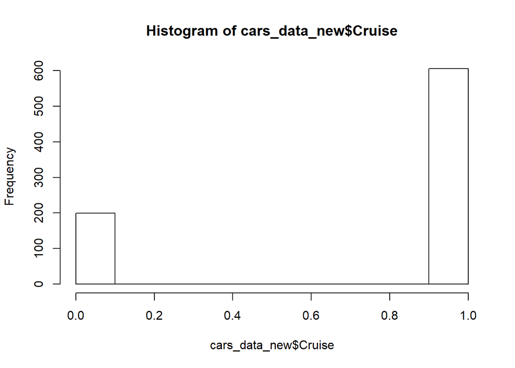

```r
hist(cars_data_new$Cruise)
```

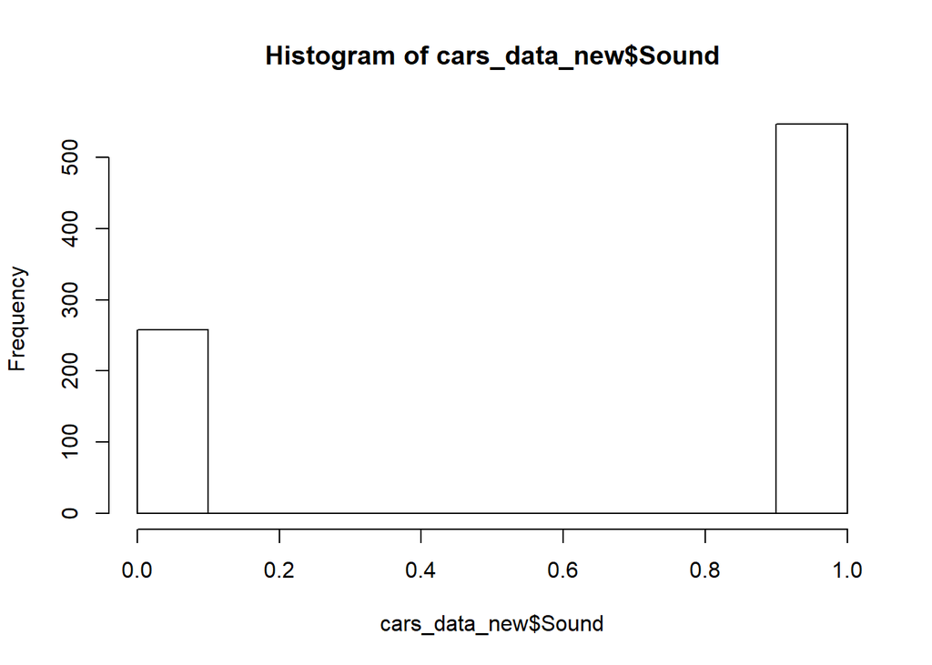

```r
hist(cars_data_new$Sound)
```

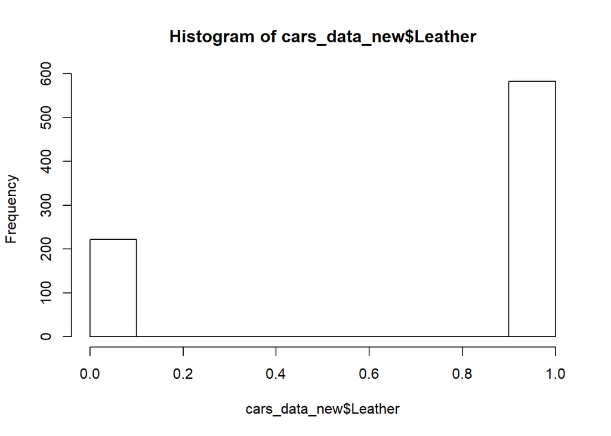

```r
hist(cars_data_new$Leather)
```

```r
#Cylinder, Doors, Cruise, Leather, Sound are categorical no need for distribution transformation. And Mileage is normally distributed so we apply the log transformations only to Liter and Price

#Transforming price column using log10 tranformation.
summary(na.exclude(cars_data_new$Price))
```

```
##    Min. 1st Qu.  Median    Mean 3rd Qu.    Max.
##    8639   14222   17945   20781   25959   49248
```

```r
summary(na.exclude(log10(cars_data_new$Price)))
```

```
##    Min. 1st Qu.  Median    Mean 3rd Qu.    Max.
##   3.936   4.153   4.254   4.284   4.414   4.692
```

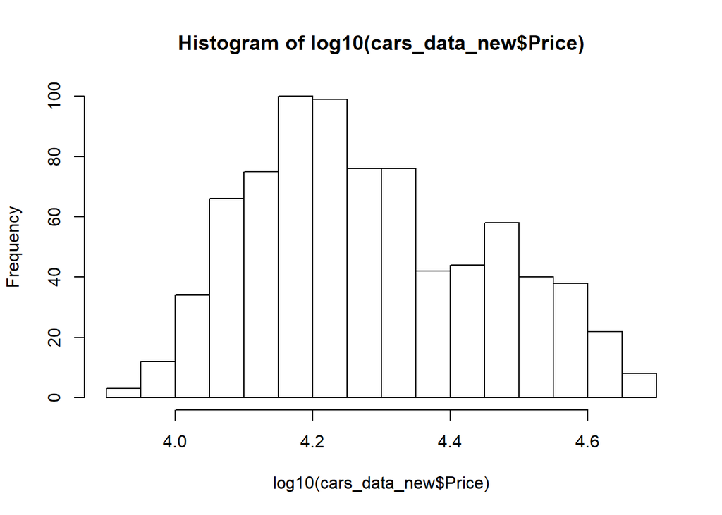

```r
hist(log10(cars_data_new$Price))
```

```r
cars_data_new$Price <- log10(cars_data_new$Price)

#Lowest skewness value was observed for log10 transformation
skewness(cars_data_new$Price,na.rm = TRUE)
```

```
## [1] 0.3753774
```

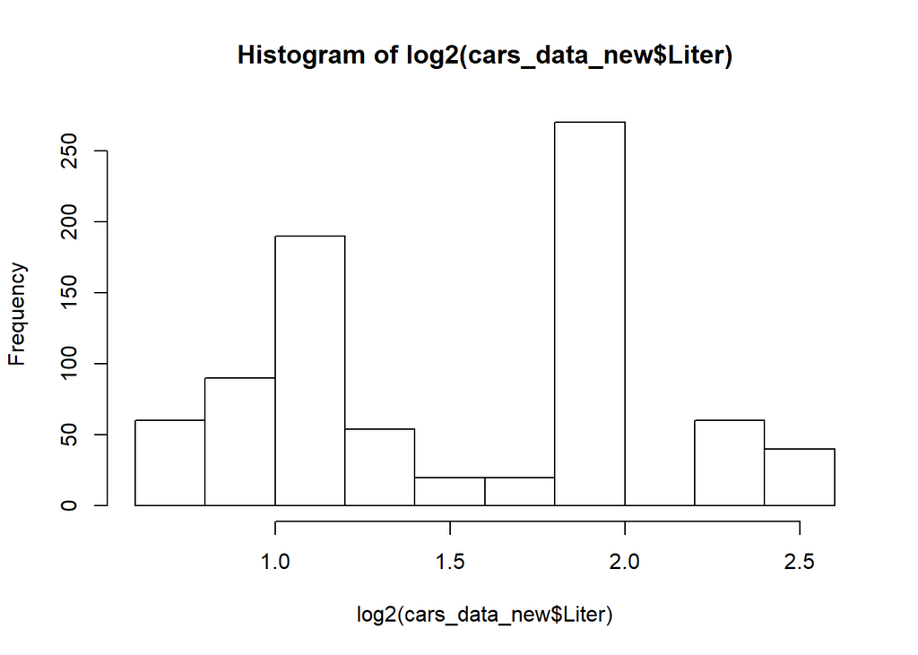

```r
#For liter column we observe no change so we do not transform it
hist(log2(cars_data_new$Liter))
```

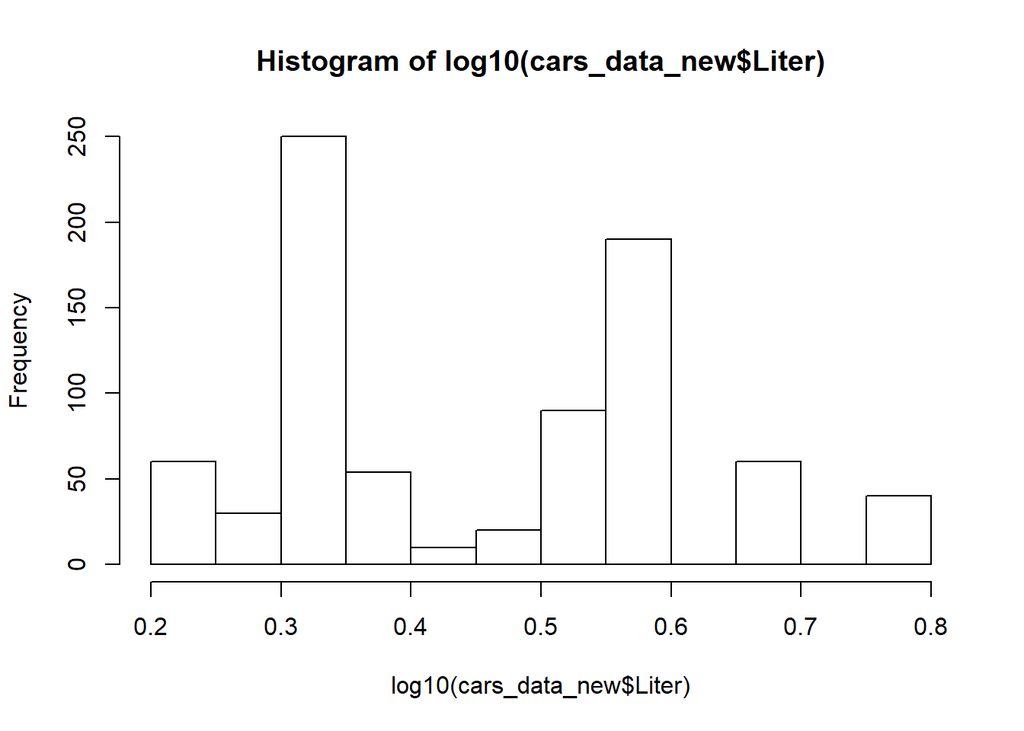

```r
hist(log10(cars_data_new$Liter))
```

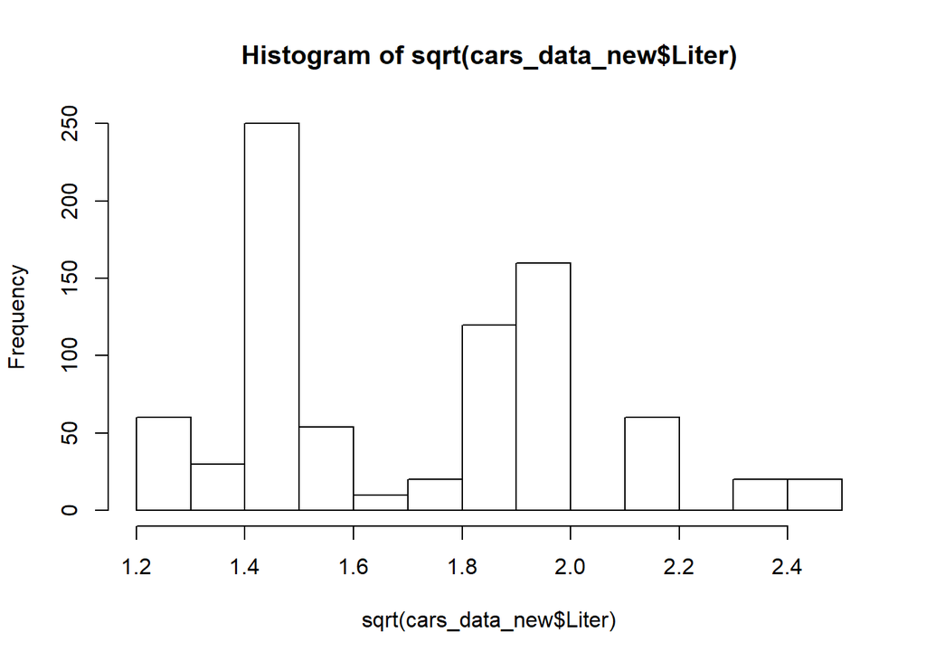

```r
hist(sqrt(cars_data_new$Liter))
```

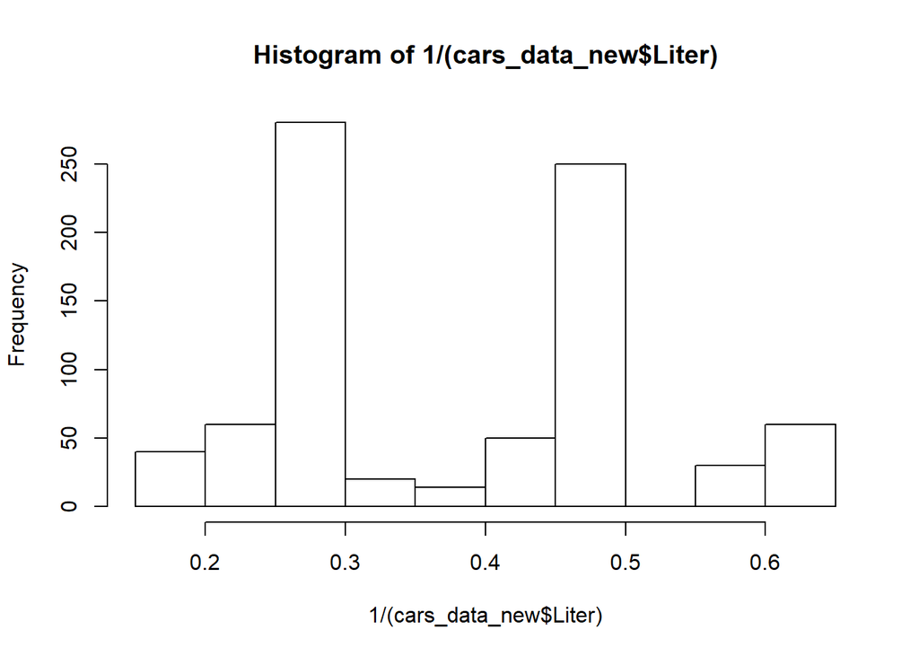

```r
hist(1/(cars_data_new$Liter))
```

```r
#cars_data_new$Liter <- log2(cars_data_new$Liter)
```

4. What are the correlations to the response variable (car sales price) and are there collinearities? Build a full correlation matrix.
- First we make the correlation matrix of price vs all other features
- Later we make whole correlation matrix which consist of correlations between all features
- We use corrplot function to plot the correlation which gives better understanding of how well each variable is correlated to other
- We observe cylinder, Liter and Cruise are highly correlated to price.
- Apart from that we observe that sound has the lowest correlation with price column

```r
cor(cars_data[1],cars_data[c(-1,-3)])
```

```
##          Mileage  Cylinder     Liter      Doors    Cruise      Sound   Leather
## Price -0.1430505 0.5690861 0.5581458 -0.1387497 0.4308515 -0.1243478 0.1571969
```

```r
cor(cars_data[-3])
```

```
##               Price      Mileage    Cylinder       Liter       Doors
## Price     1.0000000 -0.143050506  0.56908614  0.55814581 -0.13874965
## Mileage  -0.1430505  1.000000000 -0.02946099 -0.01864062 -0.01694449
## Cylinder  0.5690861 -0.029460989  1.00000000  0.95789658  0.00220592
## Liter     0.5581458 -0.018640622  0.95789658  1.00000000 -0.07925909
## Doors    -0.1387497 -0.016944490  0.00220592 -0.07925909  1.00000000
## Cruise    0.4308515  0.025036652  0.35428485  0.37750927 -0.04767418
## Sound    -0.1243478 -0.026145926 -0.08970430 -0.06552707 -0.06253031
## Leather   0.1571969  0.001005446  0.07551962  0.08733194 -0.06196858
##               Cruise       Sound      Leather
## Price     0.43085149 -0.12434785  0.157196855
## Mileage   0.02503665 -0.02614593  0.001005446
## Cylinder  0.35428485 -0.08970430  0.075519616
## Liter     0.37750927 -0.06552707  0.087331945
## Doors    -0.04767418 -0.06253031 -0.061968579
## Cruise    1.00000000 -0.09173015 -0.070573094
## Sound    -0.09173015  1.00000000  0.165443625
## Leather  -0.07057309  0.16544362  1.000000000
```

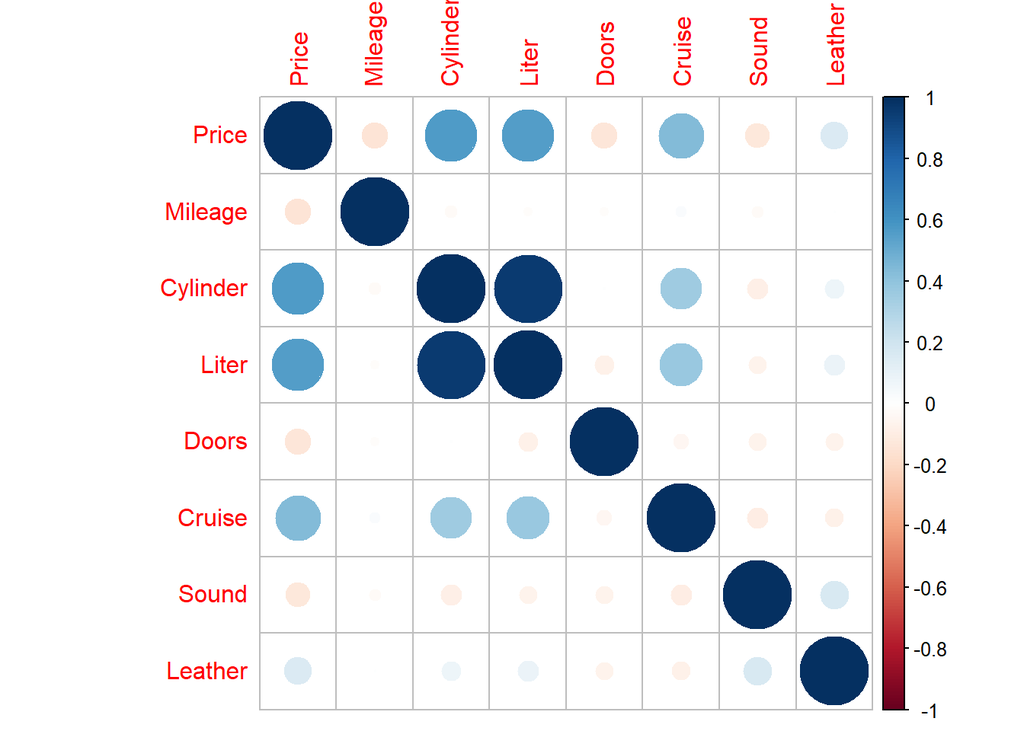

```r
corrplot::corrplot(cor(cars_data[-3]))
```

5. Split the data set 75/25 so you retain 25% for testing using random sampling.
- Again we use set.seed for random sampling along with createDataPartition function for partitioning

```r
#Set seed for random sampling
set.seed(1)

#createDataPartition function for partitioning
index <- createDataPartition(cars_data$Make, p=0.75, list = FALSE, times = 1)
cars_training_data <- cars_data[index, ]
cars_testing_data <- cars_data[-index, ]

#We create separate training and testing for new dataset in which outliers are removed
cars_new_training <- cars_data_new[index,]
cars_new_testing <- cars_data_new[-index,]

cars_new_training <- na.exclude(cars_new_training)
cars_new_testing <- na.exclude(cars_new_testing)
```

6. Build a full multiple regression model for predicting car sales prices in this data set using the complete training data set (no outliers removed), i.e., a regression model that contains all features regardless of their p-values.
- lm function is used for multiple linear regression
- We train the model using training dataset
- Using summary function we can observe the p-value and adjusted r-squared value of the model along with significance of each variable
- Adjusted R-squared value is 0.8803 which is fairly good with a low p-value
- We observe a very high RMSE value because we havem’t removed any features

```r
#using lm for linear regression
cars_pred <- lm(Price~.,data = cars_training_data)
summary(cars_pred)
```

```
##
## Call:
## lm(formula = Price ~ ., data = cars_training_data)
##
## Residuals:
##     Min      1Q  Median      3Q     Max
## -9619.4 -1738.9  -173.9  1312.6 22693.4
##
## Coefficients:
##                 Estimate Std. Error t value Pr(>|t|)
## (Intercept)    1.595e+04  1.463e+03  10.906  < 2e-16 ***
## Mileage       -1.752e-01  1.686e-02 -10.393  < 2e-16 ***
## MakeCadillac   1.686e+04  7.574e+02  22.262  < 2e-16 ***
## MakeChevrolet -1.960e+03  5.596e+02  -3.503 0.000494 ***
## MakePontiac   -1.461e+03  5.746e+02  -2.542 0.011273 *
## MakeSAAB       1.471e+04  6.735e+02  21.844  < 2e-16 ***
## MakeSaturn    -2.234e+03  7.498e+02  -2.979 0.003009 **
## Cylinder      -4.253e+02  4.554e+02  -0.934 0.350730
## Liter          4.924e+03  5.263e+02   9.357  < 2e-16 ***
## Doors         -1.681e+03  1.787e+02  -9.408  < 2e-16 ***
## Cruise        -2.486e+02  3.902e+02  -0.637 0.524354
## Sound         -8.362e+01  3.179e+02  -0.263 0.792604
## Leather       -2.025e+02  3.532e+02  -0.573 0.566688
## ---
## Signif. codes:  0 '***' 0.001 '**' 0.01 '*' 0.05 '.' 0.1 ' ' 1
##
## Residual standard error: 3435 on 591 degrees of freedom
## Multiple R-squared:  0.8827, Adjusted R-squared:  0.8803
## F-statistic: 370.5 on 12 and 591 DF,  p-value: < 2.2e-16
```

```r
#Output_pred <- predict(cars_pred,cars_testing_data)

#Root mean squared value of the model
RMSE <- sqrt(mean(cars_pred$residuals^2))
sprintf("RMSE of problem 2.6 model %s",RMSE)
```

```
## [1] "RMSE of problem 2.6 model 3397.72049979153"
```

7. Build an ideal multiple regression model using backward elimination based on p-value for predicting car sales prices in this data set using the complete training data set with outliers removed (Question 2) and features transformed (Question 3). Provide a detailed analysis of the model using the training data set with outliers removed and features transformed, including Adjusted R-Squared, RMSE, and p-values of all coefficients.
- We use lm function on new training data without outliers
- We use backward elimination method based on p-values. We observe that leather is insignificant as it has p value > 0.05
- After removing leather we remove Cruise and later Sound.
- The observed adjusted r-squared value of the model is 0.9305 which is better than the previous model because here we removed insignificant columns
- The RMSE value of the model is very low which is 0.044 which means very less error is present in the model
- P-value of leather : 0.8399, Cruise : 0.1633, Sound : 0.1280, for all other coefficients it is lower than 0.05

```r
#Creating new predictor for new training dataset without outliers
cars_new_pred_all <- lm(Price~. , data = cars_new_training)
summary(cars_new_pred_all)
```

```
##
## Call:
## lm(formula = Price ~ ., data = cars_new_training)
##
## Residuals:
##       Min        1Q    Median        3Q       Max
## -0.131470 -0.027358 -0.001287  0.025466  0.121850
##
## Coefficients:
##                 Estimate Std. Error t value Pr(>|t|)
## (Intercept)    4.118e+00  1.911e-02 215.525  < 2e-16 ***
## Mileage       -3.475e-06  2.283e-07 -15.219  < 2e-16 ***
## MakeCadillac   2.062e-01  1.006e-02  20.503  < 2e-16 ***
## MakeChevrolet -5.675e-02  7.295e-03  -7.780 3.33e-14 ***
## MakePontiac   -2.502e-02  7.485e-03  -3.342 0.000885 ***
## MakeSAAB       2.864e-01  8.786e-03  32.594  < 2e-16 ***
## MakeSaturn    -5.521e-02  9.757e-03  -5.659 2.40e-08 ***
## Cylinder      -2.075e-02  6.060e-03  -3.425 0.000659 ***
## Liter          1.173e-01  7.013e-03  16.730  < 2e-16 ***
## Doors         -1.047e-02  2.438e-03  -4.295 2.04e-05 ***
## Cruise         6.935e-03  5.078e-03   1.366 0.172609
## Sound         -5.998e-03  4.182e-03  -1.434 0.152056
## Leather       -9.294e-04  4.600e-03  -0.202 0.839966
## ---
## Signif. codes:  0 '***' 0.001 '**' 0.01 '*' 0.05 '.' 0.1 ' ' 1
##
## Residual standard error: 0.04468 on 580 degrees of freedom
## Multiple R-squared:  0.9321, Adjusted R-squared:  0.9307
## F-statistic: 663.6 on 12 and 580 DF,  p-value: < 2.2e-16
```

```r
#Removing Leather based on high p-value
cars_new_pred <- lm(Price~ Mileage+Make+Cylinder+Liter+Doors+Sound+Cruise, data = cars_new_training)
summary(cars_new_pred)
```

```
##
## Call:
## lm(formula = Price ~ Mileage + Make + Cylinder + Liter + Doors +
##     Sound + Cruise, data = cars_new_training)
##
## Residuals:
##       Min        1Q    Median        3Q       Max
## -0.130652 -0.027569 -0.001296  0.025422  0.122301
##
## Coefficients:
##                 Estimate Std. Error t value Pr(>|t|)
## (Intercept)    4.117e+00  1.888e-02 218.081  < 2e-16 ***
## Mileage       -3.476e-06  2.280e-07 -15.244  < 2e-16 ***
## MakeCadillac   2.056e-01  9.580e-03  21.464  < 2e-16 ***
## MakeChevrolet -5.707e-02  7.121e-03  -8.014 6.13e-15 ***
## MakePontiac   -2.524e-02  7.393e-03  -3.414 0.000684 ***
## MakeSAAB       2.861e-01  8.655e-03  33.053  < 2e-16 ***
## MakeSaturn    -5.527e-02  9.745e-03  -5.671 2.24e-08 ***
## Cylinder      -2.057e-02  5.986e-03  -3.436 0.000632 ***
## Liter          1.171e-01  6.886e-03  16.999  < 2e-16 ***
## Doors         -1.047e-02  2.436e-03  -4.299 2.02e-05 ***
## Sound         -6.110e-03  4.142e-03  -1.475 0.140686
## Cruise         7.043e-03  5.046e-03   1.396 0.163304
## ---
## Signif. codes:  0 '***' 0.001 '**' 0.01 '*' 0.05 '.' 0.1 ' ' 1
##
## Residual standard error: 0.04464 on 581 degrees of freedom
## Multiple R-squared:  0.9321, Adjusted R-squared:  0.9308
## F-statistic: 725.1 on 11 and 581 DF,  p-value: < 2.2e-16
```

```r
#Removing Cruise based on high p-value
cars_new_pred <- lm(Price~ Mileage+Make+Cylinder+Liter+Doors+Sound, data = cars_new_training)
summary(cars_new_pred)
```

```
##
## Call:
## lm(formula = Price ~ Mileage + Make + Cylinder + Liter + Doors +
##     Sound, data = cars_new_training)
##
## Residuals:
##       Min        1Q    Median        3Q       Max
## -0.130817 -0.027119 -0.000511  0.025134  0.125877
##
## Coefficients:
##                 Estimate Std. Error t value Pr(>|t|)
## (Intercept)    4.121e+00  1.873e-02 220.041  < 2e-16 ***
## Mileage       -3.472e-06  2.282e-07 -15.214  < 2e-16 ***
## MakeCadillac   2.048e-01  9.569e-03  21.401  < 2e-16 ***
## MakeChevrolet -5.919e-02  6.962e-03  -8.502  < 2e-16 ***
## MakePontiac   -2.686e-02  7.307e-03  -3.676 0.000259 ***
## MakeSAAB       2.877e-01  8.582e-03  33.522  < 2e-16 ***
## MakeSaturn    -5.795e-02  9.562e-03  -6.060 2.44e-09 ***
## Cylinder      -2.044e-02  5.990e-03  -3.413 0.000688 ***
## Liter          1.180e-01  6.856e-03  17.216  < 2e-16 ***
## Doors         -1.066e-02  2.434e-03  -4.380 1.41e-05 ***
## Sound         -6.314e-03  4.143e-03  -1.524 0.128026
## ---
## Signif. codes:  0 '***' 0.001 '**' 0.01 '*' 0.05 '.' 0.1 ' ' 1
##
## Residual standard error: 0.04468 on 582 degrees of freedom
## Multiple R-squared:  0.9319, Adjusted R-squared:  0.9307
## F-statistic: 796.1 on 10 and 582 DF,  p-value: < 2.2e-16
```

```r
#Removing Sound on high p-value
cars_new_pred <- lm(Price~ Mileage+Make+Cylinder+Liter+Doors, data = cars_new_training)
summary(cars_new_pred)
```

```
##
## Call:
## lm(formula = Price ~ Mileage + Make + Cylinder + Liter + Doors,
##     data = cars_new_training)
##
## Residuals:
##       Min        1Q    Median        3Q       Max
## -0.133363 -0.026965 -0.000212  0.025231  0.130143
##
## Coefficients:
##                 Estimate Std. Error t value Pr(>|t|)
## (Intercept)    4.114e+00  1.824e-02 225.527  < 2e-16 ***
## Mileage       -3.467e-06  2.284e-07 -15.176  < 2e-16 ***
## MakeCadillac   2.048e-01  9.580e-03  21.379  < 2e-16 ***
## MakeChevrolet -6.016e-02  6.941e-03  -8.667  < 2e-16 ***
## MakePontiac   -2.661e-02  7.314e-03  -3.638 0.000299 ***
## MakeSAAB       2.889e-01  8.558e-03  33.754  < 2e-16 ***
## MakeSaturn    -5.649e-02  9.525e-03  -5.931 5.17e-09 ***
## Cylinder      -1.962e-02  5.973e-03  -3.285 0.001081 **
## Liter          1.174e-01  6.853e-03  17.138  < 2e-16 ***
## Doors         -1.072e-02  2.437e-03  -4.401 1.28e-05 ***
## ---
## Signif. codes:  0 '***' 0.001 '**' 0.01 '*' 0.05 '.' 0.1 ' ' 1
##
## Residual standard error: 0.04473 on 583 degrees of freedom
## Multiple R-squared:  0.9316, Adjusted R-squared:  0.9305
## F-statistic: 882.3 on 9 and 583 DF,  p-value: < 2.2e-16
```

```r
#Output_pred <- predict(cars_new_pred,cars_new_testing)

#Root mean squared value of the model
RMSE <- sqrt(mean(cars_new_pred$residuals^2))
sprintf("RMSE of problem 2.7 model %s",RMSE)
```

```
## [1] "RMSE of problem 2.7 model 0.0443480944261596"
```

8. On average, by how much do we expect a leather interior to change the resale value of a car based on the models built in (6) and in (7)? Note that 1 indicates the presence of leather in the car.
- For model present in problem 2.6 with all features, if leather is present then price changes by 202.4813 dollars
- For model present in problem 2.7 with significant features, we observe that leather is not present in the model prediction so price is not affected by the presence of leather
- To get the prediction of price based on presence of leather we use coefficients and mean of all columns.
- Just for comparison it tried to get difference with only leather coefficient and output was the same.

```r
#Getting coefficients of each
cars_pred$coefficients
```

```
##   (Intercept)       Mileage  MakeCadillac MakeChevrolet   MakePontiac
## 15950.7794842    -0.1751824 16861.1210301 -1960.3646152 -1460.7121182
##      MakeSAAB    MakeSaturn      Cylinder         Liter         Doors
## 14711.6131741 -2233.7741387  -425.3479235  4924.2005233 -1680.8007215
##        Cruise         Sound       Leather
##  -248.5652167   -83.6209549  -202.4812596
```

```r
#Method 1 : Using all coefficients and presence of leather
sales_Leather_0 <- 15996.6970249 - 0.1764495*(mean(cars_training_data$Mileage)) +(16194.9124775-2116.2757394-1835.3805325+14636.3226561-2190.9756008/5)*mean(as.numeric(cars_data$Make))-448.5432987*mean(cars_training_data$Cylinder)+4950.9249821*mean(cars_training_data$Liter)-1713.3570585*mean(cars_training_data$Doors)-353.2058696*mean(cars_training_data$Cruise)+147.1521336*mean(cars_training_data$Sound)-202.4812596*0

sales_Leather_1 <- 15996.6970249 - 0.1764495 *(mean(cars_training_data$Mileage))+(16194.9124775-2116.2757394-1835.3805325+14636.3226561-2190.9756008/5)*mean(as.numeric(cars_data$Make))-448.5432987*mean(cars_training_data$Cylinder)+ 4950.9249821*mean(cars_training_data$Liter)-1713.3570585*mean(cars_training_data$Doors)-353.2058696*mean(cars_training_data$Cruise)+147.1521336*mean(cars_training_data$Sound)-202.4812596*1

change <- sales_Leather_0 - sales_Leather_1
sprintf("Change in price using method 1 %s",change)
```

```
## [1] "Change in price using method 1 202.481259599997"
```

```r
#Method 2 : Using only presence of leather and its coefficient
sales_Leather_0 <- cars_pred$coefficients["Leather"] * 0
sales_Leather_1 <- cars_pred$coefficients["Leather"] * 1

change <- sales_Leather_0 - sales_Leather_1

sprintf("Change in price using method 2 %s",change)
```

```
## [1] "Change in price using method 2 202.481259593748"
```

```r
#One thing I observe is that in the end all coefficients will get subtracted so we can use method 2
```

9. Using the regression models of (6) and (7) what are the predicted resale prices of a 2005 4-door Saab with 61,435 miles with a leather interior, a 4-cylinder 2.3 liter engine, cruise control, and a premium sound system? Why are the predictions different?
- We have used the sample we created before.
- Using both models from 2.6 and 2.7 problem we predict the value of sample case.
- Predicted value for model 2.6 is 22266.46 and that for 2.7 model is 21813.08
- We get different predicted values because model 2.7 has better accuracy compared to the 2.6 model as we observe above that the RMSE for 2.6 model was very high and that for 2.7 model was very low so because of the difference in error we get difference in prediction values
- This difference is also because in model 2.6 we have selected all features where as in model 2.7 we selected significant features
- Overall we get a difference of 453.3814
10. For the regression model of (7), calculate the 95% prediction interval for the car in (9).
- About confidence interval we use the interval function present in predict which gives the 95% confidence interval for the predicted value
- By using interval = “confidence” we get the 95% CI
- The confidence interval is added in a dataframe along with the predicted value
- Along with function implementation we have separately calculated 95% CI for problem 2.7 model

```r
#Test case created before
sample
```

|  | Price | Mileage | Make | Cylinder | Liter | Doors | Cruise | Sound | Leather |
| --- | --- | --- | --- | --- | --- | --- | --- | --- | --- |
| 805 | NA | 61435 | SAAB | 4 | 2.3 | 4 | 1 | 1 | 1 |

```r
#Predicting the value for the test case along with confidence interval
sale_pred <- predict(cars_pred, sample, interval = "confidence")
sale_pred_new <- predict(cars_new_pred,sample, interval = "confidence")


sale_pred <- unname(sale_pred)
sale_pred_new <- unname(sale_pred_new)
sale_pred_new <- 10^(sale_pred_new)

difference <- sale_pred[1] - sale_pred_new[1]
sprintf("Difference between predicted values %s",difference)
```

```
## [1] "Difference between predicted values 453.381435036608"
```

```r
sale_pred <- data.frame("Predicted value" = sale_pred[1], "Lower Bound" = sale_pred[2], "Upper Bound" = sale_pred[3])
sale_pred_new <- data.frame("Predicted value" = sale_pred_new[1], "Lower Bound" = sale_pred_new[2], "Upper Bound" = sale_pred_new[3])

#Predicted value for problem 2.6 model
sale_pred
```

| Predicted.value | Lower.Bound | Upper.Bound |
| --- | --- | --- |
| 22266.46 | 20683.35 | 23849.57 |

```r
sprintf("Predicted value for problem 2.6 model %s",sale_pred[1])
```

```
## [1] "Predicted value for problem 2.6 model 22266.4609634982"
```

```r
#Predicted value for problem 2.7 model
sale_pred_new
```

| Predicted.value | Lower.Bound | Upper.Bound |
| --- | --- | --- |
| 21813.08 | 20777.6 | 22900.16 |

```r
sprintf("Predicted value for problem 2.7 model %s",sale_pred_new[1])
```

```
## [1] "Predicted value for problem 2.7 model 21813.0795284616"
```

```r
std_error <- sd(10^(cars_new_training$Price))/sqrt(nrow(cars_new_training))
lower_bound <- (sale_pred_new$Predicted.value - 1.96 * std_error)
upper_bound <- (sale_pred_new$Predicted.value + 1.96 * std_error)

sprintf("Lower bound of 95 CI %s", lower_bound )
```

```
## [1] "Lower bound of 95 CI 21111.9849281265"
```

```r
sprintf("Upper bound of 95 CI %s", upper_bound )
```

```
## [1] "Upper bound of 95 CI 22514.1741287967"
```